# Valores faltantes y series de tiempo

## Valores faltantes

Hasta este momento, hemos realizado distintos tipos de operaciones sobre conjuntos de datos que nos han permitido estimar características poblacionales con cierto grado de certidumbre. A pesar de que todos estos métodos han asumido que se trabaja con una muestra, en lugar de con el total de la población, se ha trabajado de manera exclusiva con muestras que probabilísticamente reflejan las características más importantes de la población. Sin embargo, la mayor parte de las veces en la vida real, la tasa de respuesta será imperfecta, ya sea porque fue imposible medir a algunos de los individuos de la muestra o por que los datos se perdieron en el proceso de registro. Cuando la población de ‘no respuesta’ difiere en gran medida del resto de la población —a lo largo de este notebook veremos a qué nos referimos con esto—, se genera un sesgo inherente en nuestros datos, así como en cualquier inferencia que pudieramos generar.

Hay cuatro maneras de lidiar con los valores faltantes:

1.- Prevenirlos: diseñar los métodos de colecta de información de tal manera que reduzcan la incidencia de valores faltantes lo más posible. 2.- Tomar una muestra representativa de las ‘no-respuestas’ para hacer inferencia sobre el resto de las ‘no-respuestas’. 3.- Usar modelos para predecir los valores faltantes: 3.1 Reponderado de clases. 3.2 Imputación. 4.- Ignorar los valores faltantes.

El tratamiento que le daremos a los valore faltantes dependerá de la naturaleza de los mismos. Particularmente, nos interesa identificar si los valores faltantes están asociados con otras covariables o con la variable respuesta. Los distintos tipos de valores faltantes que podemos identificar son los siguientes:

1. **Valores faltantes de forma completamente aleatoria (MCAR)**. Los valores faltantes no están asociados con la variable respuesta ni con ninguna de las covariables.
2. **Valores faltantes de forma aleatoria (MAR)**. Los valores faltantes no están asociados con la variable respuesta, sin embargo, se puede detectar asociación con otras covariables.
3. **Valores faltantes de forma no aleatoria (MNAR)**. Los valores faltantes están asociados con la variable respuesta.

Cuando estamos en el primer escenario, es particularmente fácil lidiar con los valores faltantes, ya que la presencia de los mismos no sugiere una divergencia de los principios estadísticos que hemos visto hasta ahora. Algunos de los métodos que se pueden utilizar son los siguientes:

**Eliminación de filas**

En este escenario, se eliminan todos los registros que tengan al menos un valor faltante. Este tipo de eliminación es muy estricto y puede reducir en gran medida el tamaño de los datos al dispensar registros que pudieran tener múltiples columnas sin valores faltantes. La manera más directa de llevar a cabo esta operación en R es a través de `na.omit` o `complete.cases`.

```r
data <- tibble(x = c(1, 2, 34, NA, NA),
               y = c(NA, 3, 5, 6, 7),
               z = c(1 , 1, 1, 1, 1)
               )

# na.omit
na.omit(data)
```

```
## # A tibble: 2 x 3
##       x     y     z
##   <dbl> <dbl> <dbl>
## 1     2     3     1
## 2    34     5     1
```

```r
# complete.cases
data[complete.cases(data), ]
```

```
## # A tibble: 2 x 3
##       x     y     z
##   <dbl> <dbl> <dbl>
## 1     2     3     1
## 2    34     5     1
```

```r
cov(data, use="complete.obs")
```

```
##     x  y z
## x 512 32 0
## y  32  2 0
## z   0  0 0
```

Es importante mencionar que en R, para identificar un valor faltante, se usa la función `is.na`.

**Eliminación por conjuntos**

Resulta muy similar al escenario anterior en cuanto al supuesto de valores MCAR, con la única diferencia de que los registros se preservan y son utilizados selectivamente para el cálculo de estadísticos, dependiendo si poseen el valor correspondiente para la variable de interés.

```r
cov(data, use="pairwise.complete.obs")
```

```
##          x         y z
## x 352.3333 32.000000 0
## y  32.0000  2.916667 0
## z   0.0000  0.000000 0
```

Una desventaja de este método es que usará un número distinto de entradas para el cálculo de estadísticos y, por tanto, puede producir un sesgo significativo en nuestros resultados.

**Eliminación de variables**

Cuando se observa una gran número de valores faltantes para una variable en específico, la inclusión de las mismas puede resultar perjudicial para el modelo final. Una buen regla de dedo es considerar a las variables que tienen más del 60% de valores faltantes como poco informativas y, por tanto, posibles candidatos para eliminación.

Ejercicio 1.2

Determina el porcentaje de valores nulos por columna dentro del dataset **airquality**

```
## $Ozone
## [1] 0.2418301
##
## $Solar.R
## [1] 0.04575163
##
## $Wind
## [1] 0
##
## $Temp
## [1] 0
##
## $Month
## [1] 0
##
## $Day
## [1] 0
```

Ejercicio 1.2

Realiza el mismo ejercicio pero con el dataset clean_covid

¿Qué variables tienen una gran cantidad de nulos?

¿Tiene sentido eliminarlos?

**Imputación simple**

A lo largo del curso, hemos trabajado con múltiples estadísticos de resumen, como pueden ser la media, la mediana y la moda. Estos valores pueden ser utilizados para imputar datos con las ventajas de ser simples de calcular y no alterar el valor del parámetro poblacional (imputar la media no cambia el valor de la media). Sin embargo, existen algunas desventejas; por ejemplo: no se toma en consideración la relación entre las variables, e imputar con la media tiende a reducir la varianza del conjunto de datos.

Ejercicio 1.3

Lee el archivo nfl y realiza el siguiente tratamiento:

1.- Eliminar las variables que tengan un porcentaje de valores nulos mayor a 70%.

2.- Imputar la mediana sobre las variables numéricas que tengan outliers (valores a más de 3 rangos intercuartilicos de la mediana IQ=Q3-Q1).

3.- Imputar la media sobre las variables númericas sin outliers.

4.- Imputar la moda sobre las variables categóricas.

Para estudiar métodos de imputación un poco más sofisticados es necesario dominar algunos conceptos de modelado básicos.

## Introducción al modelado estadístico

### Contexto

El paradigma del aprendizaje estadístico nace en la década de los sesenta, gracias a que el incremento en la capacidad computacional permitió llevar a cabo análisis multidimensionales de fenómenos naturales antes impracticables. Estos análisis demostraron que, en su mayoría, los modelos de baja dimensionalidad eran poco precisos e incluso completamente erróneos. Se comenzaron a cuestionar los planteamientos clásicos de la estadística y se reconoció que la mayor parte de los supuestos que la sustentaban no se cumplían cuando la complejidad del fenómeno bajo estudio aumentaba. Derivado de esto, surgieron dos maneras distintas de abordar el problema clásico de la inferencia estadıstica:

1. **El particular (paramétrico)**: busca generar métodos de estadística inferencial simples que puedan ser utilizados para resolver problemas de la vida diaria.
2. **El general (no paramétrico)**: busca encontrar un método inductivo para cualquier problema de inferencia estadística.

De esta manera, el primer paradigma parte del supuesto que:

> El investigador conoce el problema que analiza y tiene conocimiento de las causas físicas detrás de la estocasticidad de las observaciones.

Los principales supuestos que sustentan este planteamiento son los siguientes:

- La mayor parte de las relaciones funcionales subyacentes en los datos pueden ser aproximadas satisfactoriamente por una función lineal en sus parámetros.
- La normalidad es la regla subyacente en la mayor parte de los fenómenos de la naturaleza.
- La máxima verosimilitud es una buena herramienta inductiva para la estimación de parámetros.

Pese a que estos supuestos son razonables, ciertas fallas fundamentales obligaron a los investigadores y teóricos a buscar alternativas. Es curioso que dichas fallas se descubrieron en un corto periodo de tiempo: 1955-1961, mismo periodo en el que F.Rosenblatt descubrió el primer modelo de aprendizaje estadístico: el perceptrón (1958).

A razón de esto, el paradigma general no paramétrico resultó ser una alternativa prometedora. Este enfoque para el problema de inferencia estadística es mucho más conservador en cuanto al grado de conocimiento del problema y a las hipótesis subyacentes. A saber, este paradigma sostiene que:

> El investigador no tiene conocimiento confiable, a priori, de la regla estadística subyacente en el fenómeno bajo observación o de la funcion que uno quisiera aproximar.

Bajo estas líneas, es necesario preguntarse en qué medida el investigador puede hacer uso de los datos a su disposición para hacer inferencia. De aquí nace el problema del aprendizaje estadístico.

### Aprendizaje estadístico

El objetivo del aprendizaje estadístico es el diseño e implementación de algoritmos que sean capaces de *aprender* las interacciones existentes entre un conjunto de datos y un conjunto de respuestas, y generalizar dichas percepciones para observaciones futuras. En este sentido, se supondrá que existe una *regla* subyacente que rige la relación entre las variables observables y las respuestas —por el momento, sin pérdida de generalidad, nos centraremos en el contexto de clasificación binaria. Esto se debe a que es el escenario más simple de analizar, sin que esta simplicidad sacrifique generalidad. De manera concreta, supondremos un conjunto arbitrario de observaciones $X=\{x_1,x_2,\dots,x_n\}$ tal que $x_i$ se distribuyen de manera aleatoria, independiente e idénticamente distribuidas, es decir, $x_i \stackrel{iid}{\sim} D,\quad\forall x_i\in X$ y un conjunto de respuestas $Y=\{y_1, y_2, \dots,y_n\};y_i\in \{0,1\}$. Tal que existe una función $c:X\rightarrow Y$ que rige la manera en la que cada elemento $x_i$ está relacionado con una respuesta $y_i$. El problema principal del aprendizaje estadístico se reduce, entonces, a encontrar de manera **eficiente** una función o hipótesis $h:S\subset X\rightarrow Y$ donde $S\stackrel{iid}{\sim} D^n$ tal que **probablemente** estime a $c$ de manera **razonablemente correcta**.

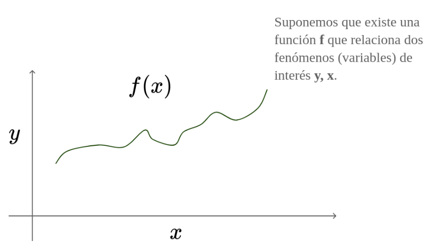

alt text

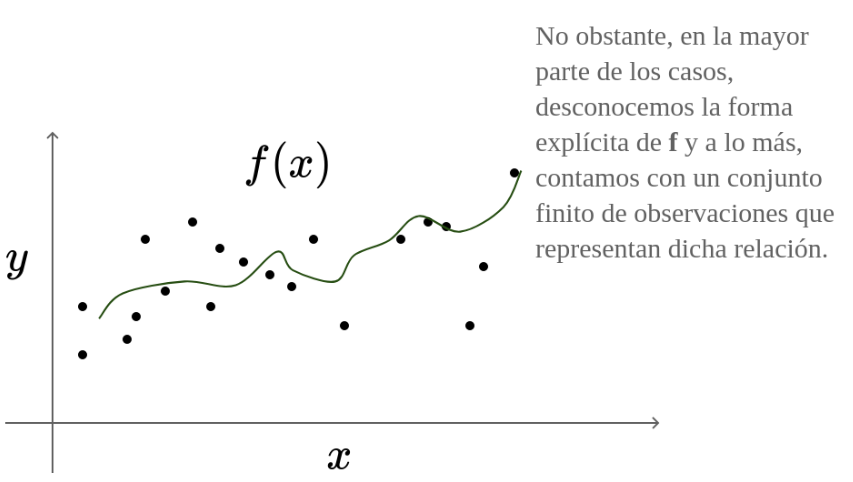

alt text

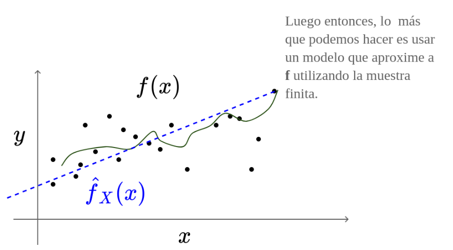

alt text

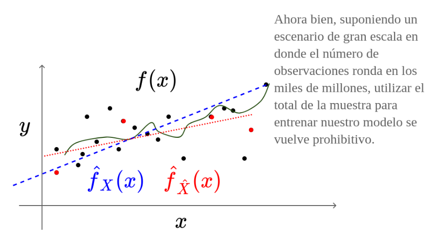

alt text

### Tipos de aprendizaje

Existen al menos tres tipos de aprendizaje estadístico; éstos varían dependiendo de la relación que existe entre los predictores y la variable respuesta —en caso de que esta existiera.

##### Aprendizaje supervisado

El objetivo principal del aprendizaje supervisado es entrenar un modelo que aprenda las interacciones que existen entre un conjunto de variables (predictores) y un conjunto de variables de salida. Por tanto, en este paradigma, se asume que la señal que quiere ser aprendida es conocida. Los tipos de aprendizaje supervisado pueden ser clasificación, en caso de que la variable de salida sea categórica, o regresión, en caso de que la variable de salida sea continua o numérica.

##### Aprendizja no supervisado

En el aprendizaje no supervisado, no tenemos etiquetas o ningún tipo de señal explícito que nos indique como se relacionan las variables; por tanto, lo que se desea es explorar la estructura de los datos con tal de extraer información significativa sobre las relaciones que existen entre los mismos. Algunos ejemplos de problemas no supervisados son clustering, detección de anomalías y reducción de dimensionalidad.

##### Aprendizaje por refuerzo

En este tipo de aprendizaje, no se cuenta con una variable de respuesta, no obstante, se cuenta con estímulos que ‘recompensan’ o ‘castigan’ a la regla de aprendizaje, dependiendo si sus decisiones fueron adecuadas.

En este módulo, nos enfocaremos en métodos de aprendizaje supervisado. Particularmente, comenzaremos con un repaso de los conceptos involucrados en modelos lineales más sencillos, para después poder integrar una componente temporal.

## Modelos lineales

Si bien este modelo para describir la interacción entre dos variables es relativamente sencillo, la comprensión de sus preceptos más esenciales será de gran ayuda cuando estudiemos series de tiempo.

En su forma más escencial tenemos $y = \phi(x) = \beta_1x + \beta_0 + \epsilon| y, x, \epsilon\in\mathbb{R}^n$ con $\epsilon_i\overset{iid}{\sim} N(0,\sigma)$.

Ahora bien, dado que no tenemos conocimiento absoluto de ninguna de las distribuciones, y a lo más tenemos una ‘muestra’ de dichas interacciones, debemos utilizar estimadores $\hat{f}(x)=\hat{\beta_1}x+\hat{\beta_0}$ y los valores de $\hat{\theta} =(\hat{\beta_1}, \hat{\beta_0})$ que minimicen la función $\mathfrak{L}_\theta(x)=\frac{1}{2n}\displaystyle\sum_{i=1}^n(y^i-\phi(x^i))^2$

Esta función tiene la propiedad adicional de ser convexa y por tanto nos permitirá usar métodos de gradiente.

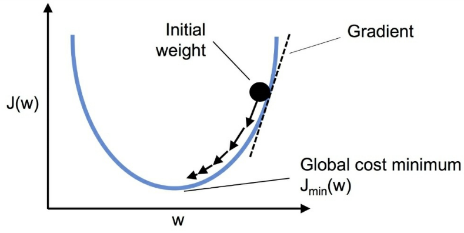

alt text

Es decir, cada vez que actualizamos los parámetros, utilizamos la dirección opuesta al gradiente. De esta manera:

$\hat{\theta} = \hat{\theta} + \Delta \hat{\theta} = \hat{\theta} - \eta\nabla_\hat{\theta} \mathfrak{L}_\hat{\theta}(x)$

Calculando derivadas parciales tenemos que, (Ejercicio, muestra el procedimiento para obtener esta derivada):

$\frac{\partial \mathfrak{L}}{\partial \beta_j}=-\frac{1}{n}\sum_{i=1}^n(y^i-\phi(x^i))x_j^i$

y por tanto

$\Delta w_j = -\eta \frac{\partial \mathfrak{L}}{\partial w_j}=-\frac{\eta}{n}\sum_{i=1}^n(y^i-\phi(x^i))x_j^i$

### Implementando regression lineal simple

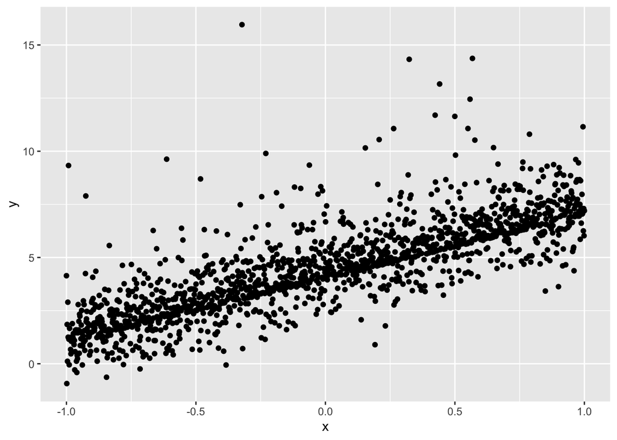

```r
n <- 1500
x <- seq(-1, 1, length.out = n)
# y <- 5*x + 3 + rnorm(n)
y <- 3*x + 4 + rnorm(n)**floor(2*runif(n) + 1)
# y <- .005*x + rnorm(n)
# y=3x+4+e^\beta
data <- tibble(x=x, y=y)
# Veamos si obtenemos las mismas betas.
ggplot(data) + geom_point(aes(x, y))
```

```r
theta <- c(runif(1), runif(1))
x_aux <- cbind(rep(1, length(x)), x)
err <- mean(y - x_aux%*%theta)**2
thresh <- 1e-6
alpha <- .003
history <- c(err)
while(err>thresh){
  theta <- theta + alpha*apply(x_aux, 2, function(t)mean(t*(y - x_aux%*%theta)))
  err <- mean(y - x_aux%*%theta)**2
  history <- c(history, err)
}
theta
```

```
##                 x
## 4.522517 2.859756
```

Ejercicio 1.2

Ejecuta el código anterior utilizando distintas tasas de aprendizaje y grafica los errores.

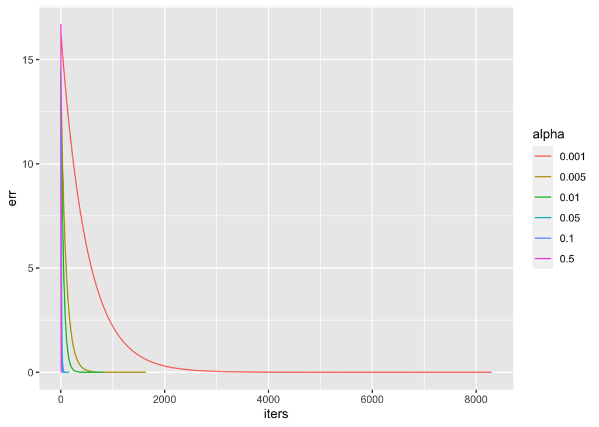

Es importante notar el efecto de la tasa de aprendizaje. Por un lado, si es demasiado grande, puede llegar a ocurrir que, en lugar de reducir el error, lo que hacemos es incrementar el valor del mismo con cada iteración. Por otra parte, si la tasa de aprendizaje es muy pequeña, podemos observar que le tomaría demasiado tiempo al algortimo alcanzar convergencia.

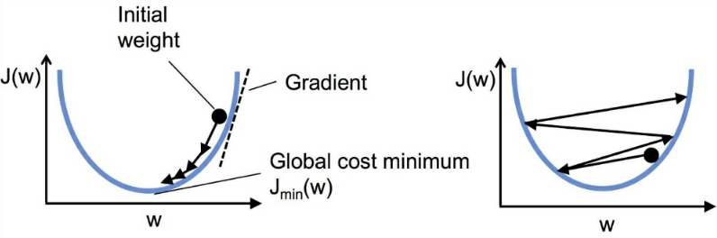

alt text

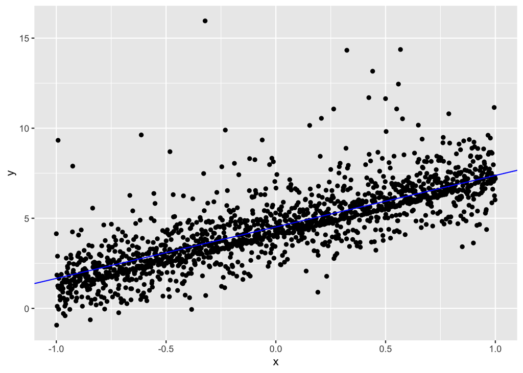

Otro factor que puede afectar la convergencia de nuestro algoritmo es grandes diferencias en la escala de nuestras variables. Esto hace que sea particularmente difícil para el gradiente obtener información relacionada con variables cuya dimensión sea menor, relativamente a otras. Para eliminar este efecto, normalizaremos los datos:

$x_j'=\frac{x_j - \mu_j}{\sigma_j}$

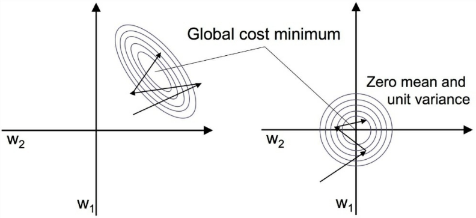

alt text

Después de tomar las debidas precauciones y ajustar los datos, veamos como se comportan los residuos.

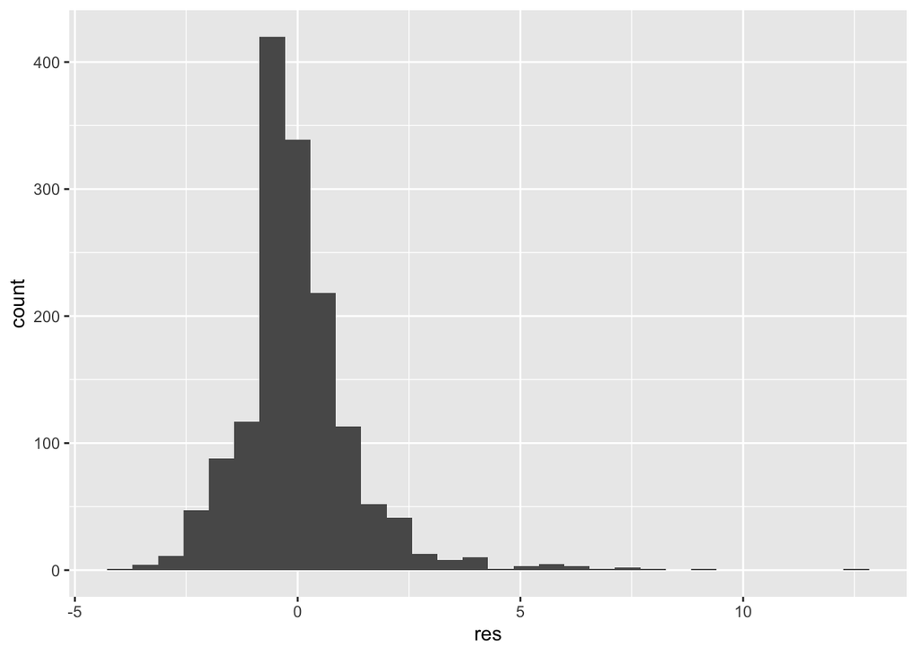

```r
res <- y - cbind(1, x)%*%theta
ggplot(tibble(res=res)) + geom_histogram(aes(x=res))
```

Ejercicio 1.4

Genera una gráfica qq entre los residuos y una normal N(0, V(res))

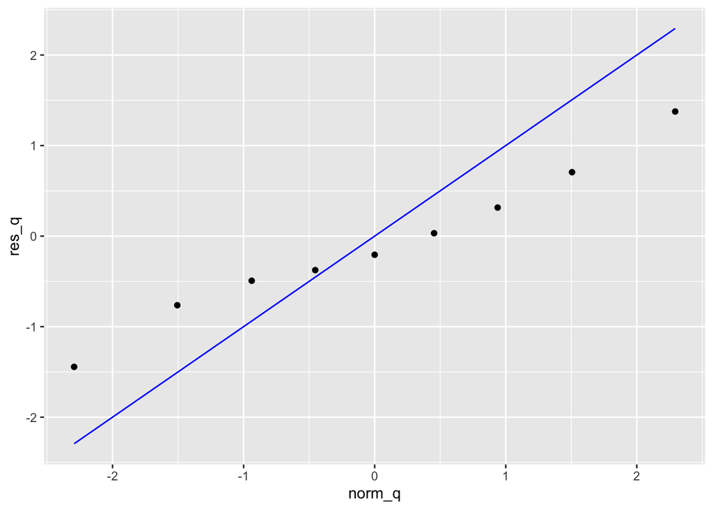

Ejercicio 1.2

Repite el ejercicio anterior, usando ahora la función

$$y = .005x+\epsilon |\epsilon\sim N(0, 1)$$

¿Qué pasa con la varianza de los errores? ¿Cuál es tu interpretación?

Usa ahora la función

$$y = 5*x+ 3*x*sin(x)+\epsilon |\epsilon\sim N(0, 2)$$
¿Qué observas? ¿Cuál es tu interpretación? ¿Parece razonable pensar que un modelo lineal sería adecuado para esta relación?

HINT: Esto nos abrirá las puertas a modelos que dependen de su propio valor en un punto temporal anterior, i.e. series de tiempo.

### Betas

Es interesante notar que cuando tenemos la distribución de los errores (**suponiendo que el proceso de muestreo se haya llevado a cabo correctamente y, por tanto, podamos asumir que la distribución muestral de los errores generaliza a la distribución poblacional**), podemos llevar a cabo inferencia sobre los parámetros de nuestro modelo de regresión.

Sin entrar en demasiados detalles (puedes corroborarlo haciendo simulación), la distribución de probabilidad de $\hat{\theta}$ está dada por $F(\hat{\theta})=N(\theta, \frac{\sigma^2}{X^TX})$ (de aquí el factor de varianza que se observó en el ejercicio anterior).

Esto, por supuesto, nos permite hacer intervalos de confianza para nuestros estimadores, tal como hemos hecho en ejercicios anteriores. ¿Pero qué ocurre cuando los errores no son normales?

Ejercicio 1.3

Generar distribución bootstrap de coeficientes

```
## # A tibble: 6 x 2
##     b_0   b_1
##   <dbl> <dbl>
## 1  4.54  2.97
## 2  4.51  2.96
## 3  4.55  3.07
## 4  4.49  3.01
## 5  4.54  3.05
## 6  4.48  3.07
```

Generar intervalos de confianza

Graficar distribución más intervalos de confianza

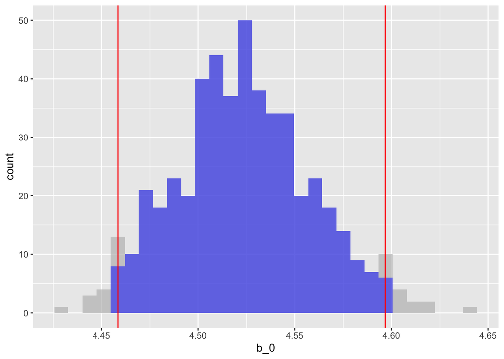

Ahora estamos en momento de trascender algunas de las limitantes de nuestro modelo. Podemos aumentar la flexibilidad del mismo, cambiando la función de conexión entre $y$ y $x$. Podemos aumentar el número de variables e interacciones. Pero una de las aplicaciones más interesantes involucra el uso de variables que están secuencialmente ligadas, en la práctica por ejemplo, por una componente temporal. A continuación, estudiaremos algunos de los planteamientos más básicos de este paradígma.

## Series de tiempo

Ya sea que deseemos predecir la tendencia en los mercados financieros o el consumo de algún producto, el tiempo es un factor importante que se debe considerarse para hacerlo acertadamente. Por ejemplo, sería interesante pronosticar a qué hora del día habrá un pico de consumo de electricidad, para así ajustar el precio o la producción de electricidad.

Una serie de tiempo es simplemente una serie de datos, representados gráficamente como puntos, ordenados en el tiempo. En ella, el tiempo suele ser la variable independiente, y el objetivo normalmente es hacer un pronóstico para el futuro.

Sin embargo, hay otros aspectos que entran en juego cuando se trata de series temporales.

### Autocorrelación

De manera informal, la autocorrelación es la similitud entre las observaciones en función del desfase temporal entre ellas. También puede entenderse como una característica que hace que observaciones cercanas en el tiempo tiempo se parezcan más entre sí que a observaciones más alejadas, únicamente por el hecho de estar cerca.

### Estacionalidad

La estacionalidad se refiere a fluctuaciones periódicas o repetitivas; patrones que gráficamente se replican durante ciertos lapsos temporales.

Ejemplos de patrones estacionales son el consumo de electricidad cada 24 horas: es alto durante el día y bajo durante la noche; o el nivel de ventas de jueguetes durante el año aumentan durante los días previos a Navidad y al día del niño, y suelen mantenerse en niveles más bajos durante el resto del año.

### Estacionariedad

La estacionariedad es una característica importante de las series de tiempo. Se dice que una serie de tiempo es estacionaria si sus propiedades estadísticas no cambian con el tiempo. Es decir, tiene media y varianza constantes, y la covarianza es independiente del tiempo.

Idealmente, queremos tener una serie de tiempo estacionaria para modelar. Pero claro que no todos los fenómenos tienen un comportamiento estacionario. Sin embargo, podemos hacer diferentes transformaciones para hacerlos estacionarios.

Existen diversas formas de modelar una serie de tiempo para hacer predicciones. Aquí se presentan brevemente un par de ellas:

### Promedios móviles

El modelo de promedios móviles es probablemente el enfoque más ingenuo para el modelado de series de tiempo. Este modelo establece como predicción que la siguiente observación es sencillamente la media de todas las observaciones pasadas.

### Suavizado exponencial

El suavizado exponencial utiliza una lógica similar a la de los promedios móviles, con la diferencia de que asigna un peso decreciente diferente a cada observación. Es decir, da menos importancia a las observaciones, a medida que nos alejamos del presente.

Matemáticamente, el suavizado exponencial se expresa como:

$$s_0=x_0
s_t = \alpha x_{t} + (1-\alpha)s_{t-1}$$

Ejercicio 1.5

Lee los datos de covid y realiza un suavizamiento exponencial para las series de tiempo de ingresos y defunciones.